# Genus-level ASCI

### Genus traits table

- The existing traits table at the species (or higher) level is formatted to show the genus designation, assigned FinalID (species or higher), trait category, and estimate for the trait.

```r
library(tidyverse)
library(ASCI)

data(taxain_spp)

# add a complete genus column to the traits lookup table
# select only the trait categories used in selected metrics
x <- pmmilkup$traits %>%
  dplyr::select(Phylum, Class, Order, Family, Genus1, FinalIDassigned, everything()) %>%
  dplyr::select(-orig.FinalID, -AlgaeList) %>%
  mutate_if(is.factor, as.character) %>%
  rowwise() %>%
  mutate(Genus1 = do({

    # use genus1 if not empty
    if(Genus1 != '')
      return(Genus1)

    chk <- c(Phylum, Class, Order, Family, Genus1)

    # get first of FinalIDassigned if all higher taxa cats are empty
    if(all(chk == '')){

      out <- strsplit(FinalIDassigned, ' ')[[1]][1]

      # get last non-empty cat
    } else {

      out <- chk[chk != ''] %>% rev %>% .[1]

    }

    return(out)

  })
  ) %>%
  dplyr::select(-Phylum, -Class, -Order, -Family) %>%
  unique %>%
  gather('trait', 'est', -Genus1, -FinalIDassigned) %>%
  rename(FinalID = FinalIDassigned) %>%
  arrange(Genus1, FinalID, trait)

print(tbl_df(x), n = 30)
```

```
## # A tibble: 51,704 x 4
##    Genus1        FinalID       trait                     est
##    <chr>         <chr>         <chr>                     <chr>
##  1 Achnanthaceae Achnanthaceae BCG                       0
##  2 Achnanthaceae Achnanthaceae BCG12                     ""
##  3 Achnanthaceae Achnanthaceae BCG45                     ""
##  4 Achnanthaceae Achnanthaceae CRUS                      ""
##  5 Achnanthaceae Achnanthaceae Green                     ""
##  6 Achnanthaceae Achnanthaceae Habit                     ""
##  7 Achnanthaceae Achnanthaceae Heterocystous             ""
##  8 Achnanthaceae Achnanthaceae IndicatorClass_Cu         ""
##  9 Achnanthaceae Achnanthaceae IndicatorClass_DOC        ""
## 10 Achnanthaceae Achnanthaceae IndicatorClass_Ref        ""
## 11 Achnanthaceae Achnanthaceae IndicatorClass_TN         ""
## 12 Achnanthaceae Achnanthaceae IndicatorClass_TP         ""
```

[output cut: 19 more lines]

- The observed species data is joined with the formatted traits table by FinalID to get counts of species within each genus, i.e., which species in a genus are more common in the dataset

```r
# join species level data with genus traits to summarize counts by data dist
to_summ <- taxain_spp %>%
  left_join(x, by = 'FinalID') %>%
  mutate(
    Genus1 = ifelse(is.na(Genus1), gsub(' .*$', '', FinalID), Genus1),
    est = ifelse(est %in% '', NA, est)
  ) %>%
  arrange(Genus1, FinalID, trait) %>%
  select(SampleID, Genus1, FinalID, trait, est)

print(tbl_df(to_summ), n = 30)
```

```
## # A tibble: 2,216,315 x 5
##    SampleID            Genus1        FinalID       trait             est
##    <chr>               <chr>         <chr>         <chr>             <chr>
##  1 105PS0028_8/12/08_1 Achnanthaceae Achnanthaceae BCG               0
##  2 105PS0028_8/26/08_1 Achnanthaceae Achnanthaceae BCG               0
##  3 105PS0028_8/12/08_1 Achnanthaceae Achnanthaceae BCG12             <NA>
##  4 105PS0028_8/26/08_1 Achnanthaceae Achnanthaceae BCG12             <NA>
##  5 105PS0028_8/12/08_1 Achnanthaceae Achnanthaceae BCG45             <NA>
##  6 105PS0028_8/26/08_1 Achnanthaceae Achnanthaceae BCG45             <NA>
##  7 105PS0028_8/12/08_1 Achnanthaceae Achnanthaceae CRUS              <NA>
##  8 105PS0028_8/26/08_1 Achnanthaceae Achnanthaceae CRUS              <NA>
##  9 105PS0028_8/12/08_1 Achnanthaceae Achnanthaceae Green             <NA>
## 10 105PS0028_8/26/08_1 Achnanthaceae Achnanthaceae Green             <NA>
## 11 105PS0028_8/12/08_1 Achnanthaceae Achnanthaceae Habit             <NA>
## 12 105PS0028_8/26/08_1 Achnanthaceae Achnanthaceae Habit             <NA>
```

[output cut: 19 more lines]

- The joined data are summarized to count the number of observations for each species in a genus

```r
# summarize trait counts by data dist
traits_gen <- to_summ %>%
  group_by(Genus1, trait, est) %>%
  summarise(n = length(est)) %>%
  group_by(Genus1, trait) %>%
  mutate(prp = n / sum(n))

print(tbl_df(traits_gen), n = 30)
```

```
## # A tibble: 10,084 x 5
##    Genus1        trait                     est       n    prp
##    <chr>         <chr>                     <chr> <int>  <dbl>
##  1 Achnanthaceae BCG                       0         2 1
##  2 Achnanthaceae BCG12                     <NA>      2 1
##  3 Achnanthaceae BCG45                     <NA>      2 1
##  4 Achnanthaceae CRUS                      <NA>      2 1
##  5 Achnanthaceae Green                     <NA>      2 1
##  6 Achnanthaceae Habit                     <NA>      2 1
##  7 Achnanthaceae Heterocystous             <NA>      2 1
##  8 Achnanthaceae IndicatorClass_Cu         <NA>      2 1
##  9 Achnanthaceae IndicatorClass_DOC        <NA>      2 1
## 10 Achnanthaceae IndicatorClass_Ref        <NA>      2 1
## 11 Achnanthaceae IndicatorClass_TN         <NA>      2 1
## 12 Achnanthaceae IndicatorClass_TP         <NA>      2 1
```

[output cut: 19 more lines]

- Traits are assigned to the genus level if more than 75% of species in the genus have a given trait, otherwise NA. Assignments at higher taxonomic resolution (e.g., family) remain the same.

```r
traits_gen <- traits_gen %>%
  group_by(Genus1, trait) %>%
  filter(prp > 0.75) %>%
  ungroup %>%
  dplyr::select(-prp, -n) %>%
  spread(trait, est) %>%
  rename(FinalIDassigned = Genus1)

knitr::kable(traits_gen[1:30, ])
```

| FinalIDassigned | BCG | BCG12 | BCG45 | CRUS | Green | Habit | Heterocystous | IndicatorClass_Cu | IndicatorClass_DOC | IndicatorClass_Ref | IndicatorClass_TN | IndicatorClass_TP | Motility | NitrogenUptakeMetabolism | NitrogenUptakeMetabolism2 | OxygenRequirements | Salinity | Salinity2 | Saprobity | TaxonomicGroup | TrophicState | ZHR | Zygnemataceae |  |
| --- | --- | --- | --- | --- | --- | --- | --- | --- | --- | --- | --- | --- | --- | --- | --- | --- | --- | --- | --- | --- | --- | --- | --- | --- |
| Achnanthaceae | 0 | NA | NA | NA | NA | NA | NA | NA | NA | NA | NA | NA | NA | NA | NA | NA | NA | NA | NA | NA | NA | NA | NA | NA |
| Achnanthes | NA | NA | NA | NA | NA | BN | NA | NA | NA | NA | NA | NA | NM | NA | NA | NA | NA | NA | NA | NA | NA | NA | NA | NA |
| Achnanthidiaceae | 0 | NA | NA | NA | NA | NA | NA | NA | NA | NA | NA | NA | NA | NA | NA | NA | NA | NA | NA | NA | NA | NA | NA | NA |
| Achnanthidium | NA | NA | NA | NA | NA | BN | NA | NA | NA | NA | NA | NA | NM | NAHON | NAHON | DO_100 | FB | FB | BM | NA | I | NA | NA | NA |
| Actinastrum | 0 | NA | NA | NA | Yes | NA | No | NA | NA | NA | NA | NA | NA | NA | NA | NA | NA | NA | NA | CL | NA | NA | No | NA |
| Actinocyclus | 5 | NA | yes | NA | NA | NA | NA | NA | NA | NA | NA | NA | NM | NA | NA | NA | NA | NA | NA | NA | NA | NA | NA | NA |
| Actinotaenium | NA | NA | NA | NA | NA | NA | NA | NA | NA | NA | NA | NA | NA | NA | NA | NA | NA | NA | NA | NA | NA | NA | NA | NA |
| Adlafia | NA | NA | NA | NA | NA | BN | NA | NA | NA | NA | NA | NA | MM | NA | NA | NA | F | F | NA | NA | NA | NA | NA | NA |
| Amphicampa | 0 | NA | NA | NA | NA | NA | NA | NA | NA | NA | NA | NA | NA | NA | NA | NA | NA | NA | NA | NA | NA | NA | NA | NA |
| Amphipleura | 3 | NA | NA | NA | NA | BN | NA | NA | NA | NA | NA | NA | MM | NAHON | NAHON | DO_75 | FB | FB | AMPS | NA | OM | NA | NA | NA |
| Amphora | 4 | NA | yes | NA | NA | BN | NA | NA | NA | NA | NA | NA | MM | NA | NA | NA | FB | FB | NA | NA | NA | NA | NA | NA |
| Anabaena | 0 | NA | NA | NA | NA | NA | Yes | NA | NA | NA | NA | NA | NA | NA | NA | NA | NA | NA | NA | CB | NA | Yes | No | NA |
| Anabaenopsis | 0 | NA | NA | NA | NA | NA | Yes | NA | NA | NA | NA | NA | NA | NA | NA | NA | NA | NA | NA | CB | NA | Yes | No | NA |
| Anabeana | NA | NA | NA | NA | NA | NA | NA | NA | NA | NA | NA | NA | NA | NA | NA | NA | NA | NA | NA | NA | NA | NA | NA | NA |
| Aneumastus | 0 | NA | NA | NA | NA | BN | NA | NA | NA | NA | NA | NA | NA | NA | NA | NA | NA | NA | NA | NA | NA | NA | NA | NA |
| Ankistrodesmus | NA | NA | NA | NA | Yes | NA | No | NA | NA | NA | NA | NA | NA | NA | NA | NA | NA | NA | NA | CL | NA | NA | No | NA |
| Anomoeoneis | NA | NA | NA | NA | NA | NA | NA | NA | NA | NA | NA | NA | NA | NA | NA | NA | NA | NA | NA | NA | NA | NA | NA | NA |
| Apatococcus | 0 | NA | NA | NA | Yes | NA | No | NA | NI | NI | NI | NI | NA | NA | NA | NA | NA | NA | NA | CL | NA | NA | No | NA |
| Aphanocapsa | NA | NA | NA | NA | NA | NA | No | NI | NI | NI | NI | NI | NA | NA | NA | NA | NA | NA | NA | CB | NA | NA | No | NA |
| Aphanochaete | 3 | NA | NA | NA | Yes | NA | No | NI | NI | NI | NI | NI | NA | NA | NA | NA | NA | NA | NA | CL | NA | NA | No | NA |
| Aphanocheate | NA | NA | NA | NA | NA | NA | NA | NA | NA | NA | NA | NA | NA | NA | NA | NA | NA | NA | NA | NA | NA | NA | NA | NA |
| Aphanothece | 3 | NA | NA | NA | NA | NA | No | NI | NI | NI | NI | NI | NA | NA | NA | NA | NA | NA | NA | CB | NA | NA | No | NA |
| Apiocystis | 0 | NA | NA | NA | Yes | NA | No | NA | NA | NA | NA | NA | NA | NA | NA | NA | NA | NA | NA | CL | NA | NA | No | NA |
| Ardissonea | NA | NA | NA | NA | NA | NA | NA | NA | NA | NA | NA | NA | NA | NA | NA | NA | NA | NA | NA | NA | NA | NA | NA | NA |
| Arthrospira | NA | NA | NA | NA | NA | NA | NA | NA | NA | NA | NA | NA | NA | NA | NA | NA | NA | NA | NA | NA | NA | NA | NA | NA |
| Astartiella | 0 | NA | NA | NA | NA | BN | NA | NA | NA | NA | NA | NA | NM | NA | NA | NA | NA | NA | NA | NA | NA | NA | NA | NA |
| Asterionella | 3 | NA | NA | NA | NA | P | NA | NA | NA | NA | NA | NA | NM | NAHON | NAHON | DO_75 | FB | FB | BM | NA | ME | NA | NA | NA |
| Asterococcus | 3 | NA | NA | NA | Yes | NA | No | NI | NI | NI | NI | NI | NA | NA | NA | NA | NA | NA | NA | CL | NA | NA | No | NA |
| Audouinella | 0 | NA | NA | NA | NA | NA | No | NI | NI | NI | NI | NI | NA | NA | NA | NA | NA | NA | NA | RD | NA | Yes | No | NA |
| Aulacoseira | NA | NA | NA | NA | NA | P | NA | NA | NA | NA | NA | NA | NM | NA | NA | NA | NA | NA | NA | NA | NA | NA | NA | NA |

### Indicator genus analysis

- Multipatt function (indicspecies package) requires site categories as a vector and species abundances as a matrix, row.names match for both
- Sites in development dataset grouped by ‘rc’, ‘int’, ‘str’

```r
library(tidyverse)
library(indicspecies)
library(ASCI)

data(taxain_gen)
data(sitcat)

##
# groups for indic
grpin <- sitcat %>%
  filter(cls %in% c('int', 'rc', 'str')) %>%
  mutate(
    cls = fct_recode(cls, Intermediate = 'int',  Reference = 'rc', Stressed = 'str'),
    cls = as.character(cls)
  ) %>%
  dplyr::select(-psa) %>%
  spread(SampleID, cls) %>%
  unlist

print(tbl_df(grpin), n = 30)
```

```
## # A tibble: 1,706 x 1
##    value
##  * <chr>
##  1 Intermediate
##  2 Reference
##  3 Reference
##  4 Intermediate
##  5 Reference
##  6 Intermediate
##  7 Intermediate
##  8 Reference
##  9 Reference
## 10 Reference
## 11 Reference
## 12 Reference
```

[output cut: 19 more lines]

- Abundance of genera at sites (in long format)

```r
##
# filter taxonomy data by sites in dev dataset

# format abundance ests
abuin <- taxain_gen %>%
  dplyr::select(SampleID, FinalID, BAResult, Result) %>%
  mutate(
    abund = as.numeric(pmax(BAResult, Result, na.rm = T))
  ) %>% # combine abundance
  dplyr::select(-BAResult, -Result) %>%
  group_by(SampleID, FinalID) %>%
  summarise(abund = sum(abund, na.rm = T)) %>%
  ungroup

print(tbl_df(abuin), n = 30)
```

```
## # A tibble: 68,909 x 3
##    SampleID            FinalID           abund
##    <chr>               <chr>             <dbl>
##  1 000CAT148_8/10/10_1 Achnanthidium      231
##  2 000CAT148_8/10/10_1 Adlafia             10
##  3 000CAT148_8/10/10_1 Amphora              2
##  4 000CAT148_8/10/10_1 Chantransia      17452.
##  5 000CAT148_8/10/10_1 Cocconeis           25
##  6 000CAT148_8/10/10_1 Diatoma              2
##  7 000CAT148_8/10/10_1 Geissleria          12
##  8 000CAT148_8/10/10_1 Gomphonema         173
##  9 000CAT148_8/10/10_1 Heteroleibleinia   472.
## 10 000CAT148_8/10/10_1 Meridion             2
## 11 000CAT148_8/10/10_1 Navicula            31
## 12 000CAT148_8/10/10_1 Nitzschia           19
```

[output cut: 19 more lines]

```r
# make wide format, location to rowid
abuin <- abuin %>%
  spread(FinalID, abund, fill = 0) %>%
  data.frame(stringsAsFactors = F) %>%
  remove_rownames %>%
  column_to_rownames('SampleID')

##
# make sure sites match between grpin and abuin, order is the same
grpin <- grpin[names(grpin) %in% rownames(abuin)]
abuin <- abuin %>%
  .[rownames(.) %in% names(grpin), ] %>%
  .[match(rownames(.), names(grpin)), ]
```

- Run indicator species analysis, output include:
  - the A value describes the affinity of a species for each group, this sums to one for each species across the groups, it indicates which group a species is most likely to belong
  - the B value describes the proportion of sites within a group that have a species, if found in the group
  - the final stat value for indic analysis considers A and B
  - multipatt returns a pvalue for each species
  - the species indicators can be further selected by filtering with an A or B threshold
  - the coverage function describes the proportion of sites in each group where one or more indicators are found for a given threshold, with A = 0 being the default
  - using a more conservative, larger A will remove indicator species but this can be done up to a threshold until coverage begins to decline

```r
##
# run indicator analysis
res <- multipatt(abuin, grpin, duleg = T, control = how(nperm = 999))

head(res$A)
```

```
##                  Intermediate Reference  Stressed
## Achnanthaceae       1.0000000 0.0000000 0.0000000
## Achnanthes          0.1395406 0.4587755 0.4016839
## Achnanthidiaceae    0.2557195 0.3880355 0.3562450
## Achnanthidium       0.3349034 0.5040709 0.1610257
## Actinastrum         0.0000000 0.0000000 1.0000000
## Actinocyclus        0.0000000 0.0000000 1.0000000
```

```r
head(res$B)
```

```
##                  Intermediate  Reference    Stressed
## Achnanthaceae     0.001766784 0.00000000 0.000000000
## Achnanthes        0.033568905 0.01608579 0.056962025
## Achnanthidiaceae  0.005300353 0.01072386 0.012658228
## Achnanthidium     0.855123675 0.95710456 0.814873418
## Actinastrum       0.000000000 0.00000000 0.004746835
## Actinocyclus      0.000000000 0.00000000 0.003164557
```

```r
head(res$sign)
```

```
##                  s.Intermediate s.Reference s.Stressed index       stat
## Achnanthaceae                 1           0          0     1 0.04203314
## Achnanthes                    0           0          1     3 0.15126376
## Achnanthidiaceae              0           0          1     3 0.06715229
## Achnanthidium                 0           1          0     2 0.69458520
## Actinastrum                   0           0          1     3 0.06889728
## Actinocyclus                  0           0          1     3 0.05625440
##                  p.value
## Achnanthaceae      0.574
## Achnanthes         0.455
## Achnanthidiaceae   0.816
## Achnanthidium      0.001
## Actinastrum        0.164
## Actinocyclus       0.328
```

- Significant indicator species

```r
# table of indicator species by pvalue
indic <- res$sign %>%
  rownames_to_column('FinalID') %>%
  filter(p.value < 0.05) %>%
  mutate(designation = factor(index,
                              levels = c('1', '2', '3'),
                              labels = c('Intermediate', 'Reference', 'Stressed'))

  ) %>%
  select(FinalID, designation, stat, p.value)

dim(indic)
```

```
## [1] 124   4
```

```r
head(indic)
```

```
##         FinalID designation      stat p.value
## 1 Achnanthidium   Reference 0.6945852   0.001
## 2       Adlafia   Reference 0.2891636   0.002
## 3   Amphipleura   Reference 0.3145969   0.001
## 4       Amphora    Stressed 0.6236183   0.001
## 5      Anabaena   Reference 0.4006334   0.039
## 6  Asterococcus   Reference 0.2053370   0.002
```

- Using a conservative selection of indicator species

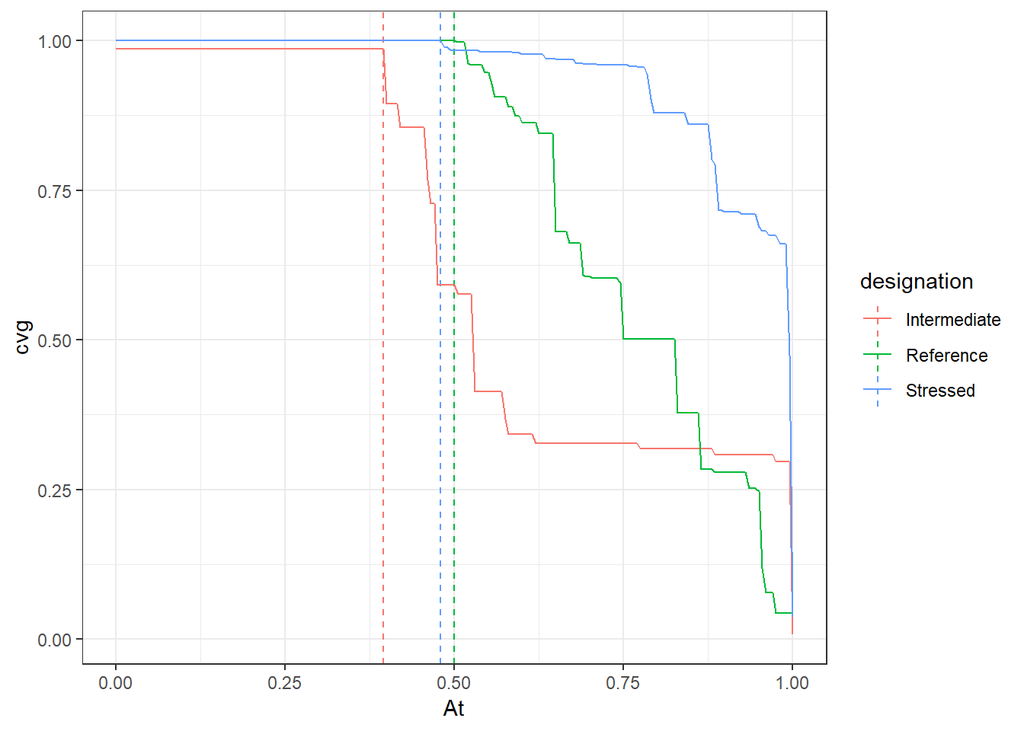

```r
# all a values
aval <- res$A %>%
  data.frame %>%
  rownames_to_column('FinalID') %>%
  gather('designation', 'aval', -FinalID)

# find maximum a values without decreasing coverage
chks <- seq(0, 1, by = 0.005)
toplo <- sapply(chks, function(At) coverage(x = abuin, y = res, At = At)) %>%
  t %>%
  data.frame %>%
  mutate(chks = chks) %>%
  gather('designation', 'cvg', -chks)
athr <- toplo %>%
  group_by(designation) %>%
  filter(cvg == max(cvg)) %>%
  filter(chks == max(chks)) %>%
  select(-cvg) %>%
  ungroup
ggplot(toplo, aes(x = chks, y = cvg, group = designation, colour = designation)) +
  geom_vline(data = athr, aes(xintercept = chks, colour = designation), linetype = 'dashed') +
  scale_x_continuous('At') +
  geom_line() +
  theme_bw()
```

```r
# join indic with a val, a threshold
indic <- indic %>%
  left_join(aval, by = c('FinalID', 'designation')) %>%
  left_join(athr, by = c('designation')) %>%
  filter(aval >= chks)

head(indic)
```

```
##         FinalID designation      stat p.value      aval chks
## 1 Achnanthidium   Reference 0.6945852   0.001 0.5040709 0.50
## 2   Amphipleura   Reference 0.3145969   0.001 0.5768166 0.50
## 3       Amphora    Stressed 0.6236183   0.001 0.4819306 0.48
## 4      Anabaena   Reference 0.4006334   0.039 0.9503039 0.50
## 5  Asterococcus   Reference 0.2053370   0.002 0.7489004 0.50
## 6   Aulacoseira   Reference 0.3263870   0.004 0.5676445 0.50
```

```r
# indicators <- indic %>%
#   dplyr::select(FinalID, designation) %>%
#   rename(FinalIDassigned = FinalID)
# save(indicators, file = 'C:/Users/Marcus.SCCWRP2K/Desktop/indicators.RData', compress = 'xz')
```

### Raw metrics

All metrics were estimated for the genus-level data using the new traits table and indicator genera.

```r
data(rawmet_gen)
data(rawmet_spp)

dim(rawmet_gen)
```

```
## [1] 1116270       5
```

```r
head(rawmet_gen)
```

```
## # A tibble: 6 x 5
##   name    SampleID            met                   val res
##   <chr>   <chr>               <chr>               <dbl> <chr>
## 1 diatoms 000CAT148_8/10/10_1 Achnanthes.richness     0 gen
## 2 diatoms 000CAT228_8/10/10_1 Achnanthes.richness     0 gen
## 3 diatoms 102PS0139_8/9/10_1  Achnanthes.richness     0 gen
## 4 diatoms 102PS0177_8/28/12_1 Achnanthes.richness     0 gen
## 5 diatoms 102PS0177_8/28/12_2 Achnanthes.richness     0 gen
## 6 diatoms 103CDCHHR_9/14/10_1 Achnanthes.richness     0 gen
```

```r
unique(rawmet_gen$met)
```

```
##   [1] "Achnanthes.richness"              "Amphora.richness"
##   [3] "cnt.spp.BCG1"                     "cnt.spp.BCG12"
##   [5] "cnt.spp.BCG2"                     "cnt.spp.BCG3"
##   [7] "cnt.spp.BCG4"                     "cnt.spp.BCG45"
##   [9] "cnt.spp.BCG5"                     "cnt.spp.BCG6"
##  [11] "cnt.spp.CRUS"                     "cnt.spp.Green"
##  [13] "cnt.spp.Halo"                     "cnt.spp.Heterocy"
##  [15] "cnt.spp.HighMotility"             "cnt.spp.IndicatorClass_Cu_high"
##  [17] "cnt.spp.IndicatorClass_DOC_high"  "cnt.spp.IndicatorClass_Ref"
##  [19] "cnt.spp.IndicatorClass_TN_high"   "cnt.spp.IndicatorClass_TP_high"
##  [21] "cnt.spp.IndicatorClass_TP_low"    "cnt.spp.MinMotility"
##  [23] "cnt.spp.ModMotility"              "cnt.spp.NHeterotroph"
##  [25] "cnt.spp.NonMotile"                "cnt.spp.ZHR"
##  [27] "Cocconeis.richness"               "Cyclotella.richness"
##  [29] "Cymbella.richness"                "EpiRho.richness"
```

[output cut: 64 more lines]